# PSYCH 260

2021-12-07 16:17:32

## Today’s topic

- Measuring the speed of nervous system conduction
- And, a tiny lesson in open, transparent, reproducible data science

[figure not shown]

## Question

- How fast does the nervous system conduct information?
- [Some prior evidence](https://psu-psychology.github.io/psych-260-spring-2017/lecture-notes/260-2017-03-29-somatosensation.html#15). [Spring 2017 data](https://psu-psychology.github.io/psych-260-spring-2017/lecture-notes/260-2017-04-24-speed-lab.html#18)
  - Proprioception vs. touch
- Why do we care?

## Prediction

We predict that the speed of conduction will be …

Between 17 and 50 m/s.

## Scheme

- Speed (\(s\)) = Distance (\(d\))/Time (\(t\)), then \(t=d/s\)
- Chain of participants to make distance larger
  - If typical person ~ 1.5 m, then
  - at \(s=30\) m/s, \(t = d/s \rightarrow 1.5/30\) = 0.05 secs.

## Condition 1 (ankle)

- Squeeze (pull on) ankle
- `ankle_shoulder` + `shoulder_brain` + `brain_decide` + `brain_shoulder` + `shoulder_hand`

## Measure

- sum(`ankle_shoulder`) for all participants -> Distance
- mean(time(Condition 1)) - mean(time(Condition 2)) -> Time
- Speed = Distance/Time

## Materials

- Stop watch
- Tape measure
- Paracord (for social distancing)

## Decisions

- Same hand or dominant?
- Alternate ankle/shoulder or one condition before the other?
- How many trials?
  - Fixed number?
  - When reach asymptote?

## Data files

- Data file with [body measurements](https://docs.google.com/spreadsheets/d/1dtBnYVk-_jkCbZG0m2lui6CgTZB1y3aEFrmd73ffoiQ/edit#gid=0)
  - participant, ankleshoulder (cm)
- Data file with [reaction times](https://docs.google.com/spreadsheets/d/17J7OGYs73tabvn0PQZUKNDRb5DN8roGPIbr1hN0_XOk/edit?usp=sharing)
  - trial {1…n}, condition {ankle, shoulder}, time (s)

```r
# Load R packages
suppressPackageStartupMessages(library("googledrive"))
suppressPackageStartupMessages(library("magrittr"))
suppressPackageStartupMessages(library("dplyr"))
suppressPackageStartupMessages(library("ggplot2"))
```

## Download data as CSV

```r
googledrive::drive_download(file = 'psych-260-2021-fall-distance', path = 'csv/psych-260-2021-fall-distance', type = 'csv', overwrite = TRUE)
```

```
## ! Using an auto-discovered, cached token.
```

```
##   To suppress this message, modify your code or options to clearly consent to
##   the use of a cached token.
```

```
##   See gargle's "Non-interactive auth" vignette for more details:
```

```
## ℹ The googledrive package is using a cached token for
##   'rick.o.gilmore@gmail.com'.
```

```
## File downloaded:
```

```
## • 'psych-260-2021-fall-distance'
##   <id: 1dtBnYVk-_jkCbZG0m2lui6CgTZB1y3aEFrmd73ffoiQ>
```

```
## Saved locally as:
```

```
## • 'csv/psych-260-2021-fall-distance.csv'
```

```r
googledrive::drive_download(file = 'psych-260-2021-fall-time', path = 'csv/psych-260-2021-fall-time', type = 'csv', overwrite = TRUE)
```

```
## File downloaded:
```

```
## • 'psych-260-2021-fall-time' <id: 17J7OGYs73tabvn0PQZUKNDRb5DN8roGPIbr1hN0_XOk>
```

```
## Saved locally as:
```

```
## • 'csv/psych-260-2021-fall-time.csv'
```

## Reimport data

```r
distance_all <-readr::read_csv("csv/psych-260-2021-fall-distance.csv")
```

```
## * `` -> ...3
```

```r
distance <- distance_all %>%
  select(participant.id, ankleshoulder)

time <- readr::read_csv("csv/psych-260-2021-fall-time.csv")
```

## Measuring distance

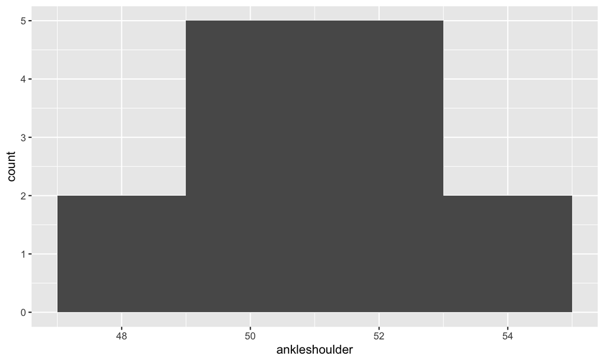

```r
dist.hist <- ggplot(data = distance, aes(x=ankleshoulder)) +
  geom_histogram(bins = 5)
```

## Sum distance

```r
with(distance, summary(ankleshoulder))
```

```
##    Min. 1st Qu.  Median    Mean 3rd Qu.    Max.    NA's
##   47.00   50.50   51.50   51.39   52.50   55.00      10
```

```r
# Calculate sum
dist.sum = with(distance, sum(ankleshoulder, na.rm = TRUE))
```

The total distance is 719.5 cm.

## Measuring time

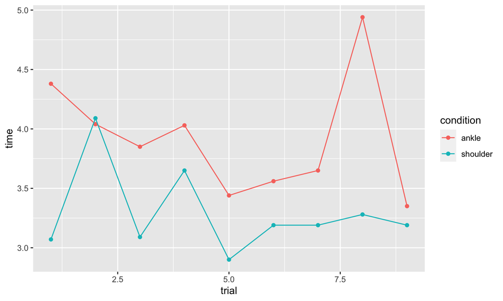

```r
# Plot data
time.plot = ggplot(data = time, aes(x=trial, y=time, color=condition)) +
  geom_point() +
  geom_line()
```

## Calculate time difference

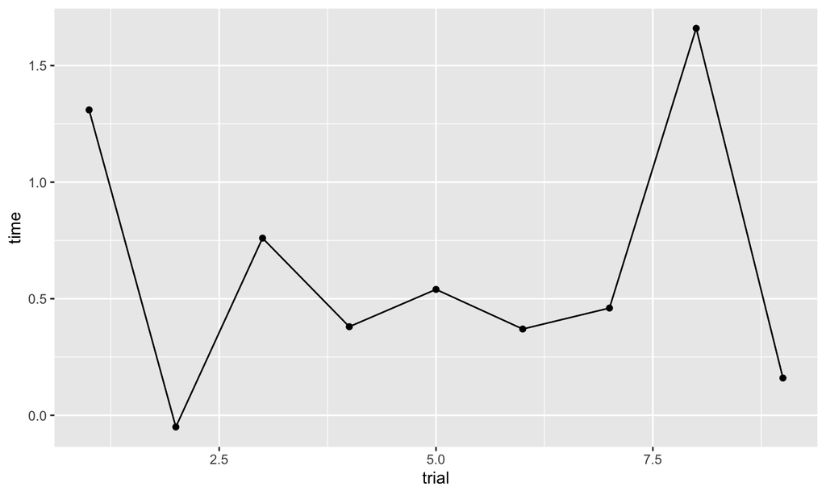

```r
time %>%
  filter(condition == "ankle") ->
  ankle.times

time %>%
  filter(condition == "shoulder") ->
  shoulder.times

time.diff <- tibble(trial=unique(time$trial),
                        time=ankle.times$time - shoulder.times$time)

time.diff.plot = ggplot(data = time.diff, aes(x=trial, y=time)) +
  geom_point() +
  geom_line()
```

## Calculating speed

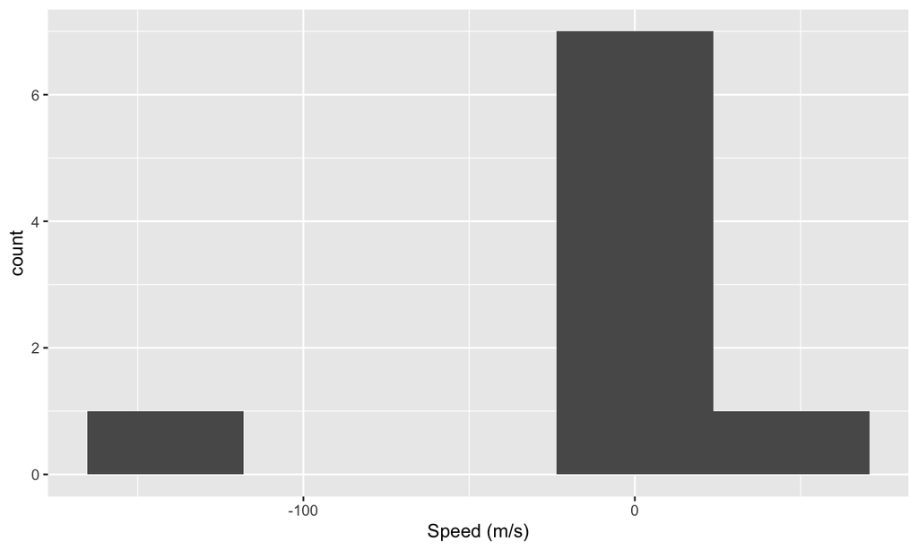

```r
cm_to_m <- 1/100
time.diff$speed <- (dist.sum)*(cm_to_m)/time.diff$time

speed.hist <- ggplot(data = time.diff, aes(x=speed)) +
  geom_histogram(bins = 5) +
  xlab("Speed (m/s)")
```

## Plot time series of speeds

```r
speed.plot <- ggplot(data = time.diff, aes(x=trial, y=speed)) +
  geom_point() +
  geom_line() +
  ylab("Speed (m/s)")
```

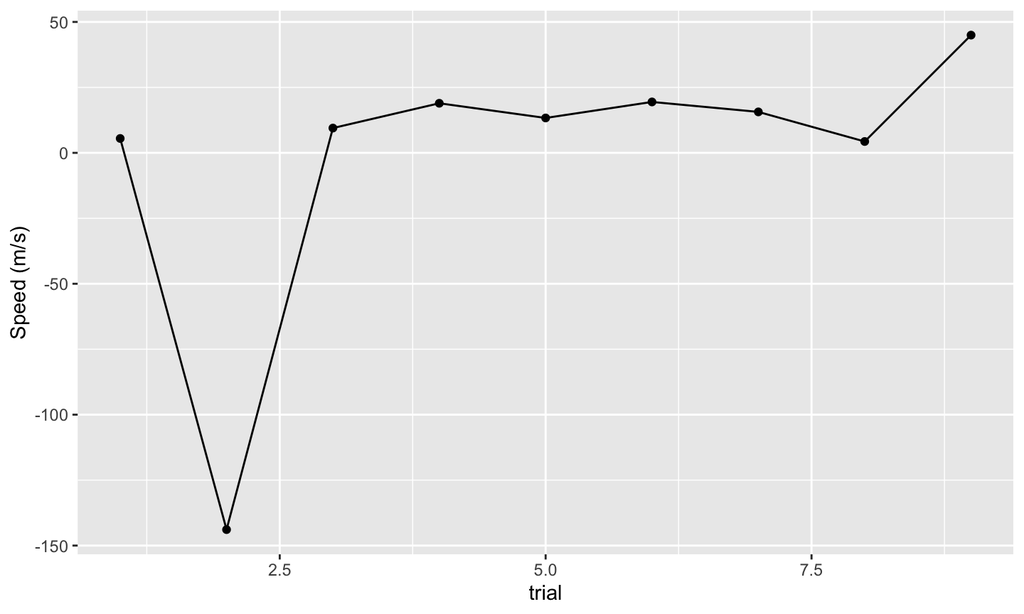

```r
speed.plot
```

## Limitations

- Sample size is small – number of participants and number of trials.
- Did not alternate ankle/shoulder conditions.
- Stopwatch made a sound. Participants could anticipate when to pull.
- Using paracord instead of actual squeezing.
- Variation in the dominant hand across participants. Didn’t record handedness as data.

## How to replicate/extend/modify

- Calculate speed after dropping outlier.

## Contributors

## Resources

This document was prepared in RStudio 1.4.717 on 2021-12-07 16:17:36.